# R for Data Science

April 10, 2019

## Part 1: Introduction

## Transformation

### Often we need to create some new variables or summarises, or maybe rename the variables or reorder the observations in order to make the data a little easier to work with

## Package

### Here we focus on the `dplyr` package, another core member of the `tidyverse`, and we'll illustrate the key ideas using data from the `nycflights13` package, and use `ggplot2` to help us understand the data.

```r
> library(nycflights13)
> library(tidyverse)
```

## Data

```r
> flights %>% print(width = Inf)
# A tibble: 336,776 x 19
    year month   day dep_time sched_dep_time dep_delay arr_time
   <int> <int> <int>    <int>          <int>     <dbl>    <int>
 1  2013     1     1      517            515         2      830
 2  2013     1     1      533            529         4      850
 3  2013     1     1      542            540         2      923
 4  2013     1     1      544            545        -1     1004
 5  2013     1     1      554            600        -6      812
 6  2013     1     1      554            558        -4      740
 7  2013     1     1      555            600        -5      913
 8  2013     1     1      557            600        -3      709
 9  2013     1     1      557            600        -3      838
10  2013     1     1      558            600        -2      753
   sched_arr_time arr_delay carrier flight tailnum origin dest  air_time
            <int>     <dbl> <chr>    <int> <chr>   <chr>  <chr>    <dbl>
 1            819        11 UA        1545 N14228  EWR    IAH        227
 2            830        20 UA        1714 N24211  LGA    IAH        227
 3            850        33 AA        1141 N619AA  JFK    MIA        160
 4           1022       -18 B6         725 N804JB  JFK    BQN        183
 5            837       -25 DL         461 N668DN  LGA    ATL        116
 6            728        12 UA        1696 N39463  EWR    ORD        150
 7            854        19 B6         507 N516JB  EWR    FLL        158
 8            723       -14 EV        5708 N829AS  LGA    IAD         53
 9            846        -8 B6          79 N593JB  JFK    MCO        140
10            745         8 AA         301 N3ALAA  LGA    ORD        138
   distance  hour minute time_hour
      <dbl> <dbl>  <dbl> <dttm>
 1     1400     5     15 2013-01-01 05:00:00
 2     1416     5     29 2013-01-01 05:00:00
 3     1089     5     40 2013-01-01 05:00:00
 4     1576     5     45 2013-01-01 05:00:00
 5      762     6      0 2013-01-01 06:00:00
 6      719     5     58 2013-01-01 05:00:00
 7     1065     6      0 2013-01-01 06:00:00
 8      229     6      0 2013-01-01 06:00:00
 9      944     6      0 2013-01-01 06:00:00
10      733     6      0 2013-01-01 06:00:00
# … with 336,766 more rows
```

## Functions

### We introduce kinds of functions to transform data, like `filter`, `arrange`, `summarise`… in next several parts

## Part II: filter

## `filter`

### `filter` allows you to subset observations based on their values.

### For example: select all flights on January 1st

```r
> filter(flights, month==1, day==1)
# A tibble: 842 x 19
    year month   day dep_time sched_dep_time dep_delay arr_time
   <int> <int> <int>    <int>          <int>     <dbl>    <int>
 1  2013     1     1      517            515         2      830
 2  2013     1     1      533            529         4      850
 3  2013     1     1      542            540         2      923
 4  2013     1     1      544            545        -1     1004
 5  2013     1     1      554            600        -6      812
 6  2013     1     1      554            558        -4      740
 7  2013     1     1      555            600        -5      913
 8  2013     1     1      557            600        -3      709
 9  2013     1     1      557            600        -3      838
10  2013     1     1      558            600        -2      753
# … with 832 more rows, and 12 more variables: sched_arr_time <int>,
#   arr_delay <dbl>, carrier <chr>, flight <int>, tailnum <chr>,
#   origin <chr>, dest <chr>, air_time <dbl>, distance <dbl>, hour <dbl>,
#   minute <dbl>, time_hour <dttm>
```

## Comparison

### Computers use finite precision arithmetic, so every number we see is an approximation. Instead of relying on `==`, use `near`:

```r
> sqrt(2)^2==2
[1] FALSE
> near(sqrt(2)^2,2)
[1] TRUE
> 1/49 *49==1
[1] FALSE
> near(1/49 *49,1)
[1] TRUE
```

## x %in% y

### Select every row where x is one of the values in y

### For example: select all flights that departed in November or December

```r
> filter(flights, month %in% c(11,12))
# A tibble: 55,403 x 19
    year month   day dep_time sched_dep_time dep_delay arr_time
   <int> <int> <int>    <int>          <int>     <dbl>    <int>
 1  2013    11     1        5           2359         6      352
 2  2013    11     1       35           2250       105      123
 3  2013    11     1      455            500        -5      641
 4  2013    11     1      539            545        -6      856
 5  2013    11     1      542            545        -3      831
 6  2013    11     1      549            600       -11      912
 7  2013    11     1      550            600       -10      705
 8  2013    11     1      554            600        -6      659
 9  2013    11     1      554            600        -6      826
10  2013    11     1      554            600        -6      749
# … with 55,393 more rows, and 12 more variables: sched_arr_time <int>,
#   arr_delay <dbl>, carrier <chr>, flight <int>, tailnum <chr>,
#   origin <chr>, dest <chr>, air_time <dbl>, distance <dbl>, hour <dbl>,
#   minute <dbl>, time_hour <dttm>
```

## Different logical operators

### `&` is "and", `|` is "or", and `!` is "not"

### For example: select flights that weren't delayed by more than two hours

```r
> f1<-filter(flights,!(arr_delay > 120|dep_delay>120))
> # or
> f2<-filter(flights, arr_delay <= 120, dep_delay <= 120)
> identical(f1,f2)
[1] TRUE
```

## Missing Values

### `NA` represents an unknown value so missing values are "contagious"; almost any operation involving an unknown value will also be unknown

```r
> NA > 5
[1] NA
> 10 == NA
[1] NA
> NA == NA
[1] NA
```

### Check if a value is missing, use `is.na`

```r
> x <- NA
> is.na(x)
[1] TRUE
```

## `NA` in `filter`

### `filter` only includes rows where the condition is `TRUE`; it exculdes both `NA` and `FALSE` values, ask for them explicitly if we want to preserve missing values

```r
> df<- tibble(x=c(1,NA,3))
> filter(df,x>1)
# A tibble: 1 x 1
      x
  <dbl>
1     3
> filter(df,is.na(x) | x>1)
# A tibble: 2 x 1
      x
  <dbl>
1    NA
2     3
```

## `between`

### filter the observations between two values

```r
> f3<-filter(flights, !(dep_time >= 2400| dep_time <=600))
> f4<-filter(flights, between(dep_time, 601, 2359))
> identical(f3,f4)
[1] TRUE
```

## Exercise 1

### 1. Finds all flights departed in summer(July, August, and September)

### 2.How many flights have a missing `dep_time`? What other variables are missing?

## Solution

### Q1. Finds all flights departed in summer(July, August, and September)

```r
> filter(flights, month %in% c(7:9))
# A tibble: 86,326 x 19
    year month   day dep_time sched_dep_time dep_delay arr_time
   <int> <int> <int>    <int>          <int>     <dbl>    <int>
 1  2013     7     1        1           2029       212      236
 2  2013     7     1        2           2359         3      344
 3  2013     7     1       29           2245       104      151
 4  2013     7     1       43           2130       193      322
 5  2013     7     1       44           2150       174      300
 6  2013     7     1       46           2051       235      304
 7  2013     7     1       48           2001       287      308
 8  2013     7     1       58           2155       183      335
 9  2013     7     1      100           2146       194      327
10  2013     7     1      100           2245       135      337
# … with 86,316 more rows, and 12 more variables: sched_arr_time <int>,
#   arr_delay <dbl>, carrier <chr>, flight <int>, tailnum <chr>,
#   origin <chr>, dest <chr>, air_time <dbl>, distance <dbl>, hour <dbl>,
#   minute <dbl>, time_hour <dttm>
```

## Q2 How many flights have a missing `dep_time`?

```r
> sum(is.na(flights$dep_time))
[1] 8255
```

```r
> #or
> flights %>% select(dep_time) %>%
+   is.na() %>% sum()
[1] 8255
> #or
> flights %>% select(dep_time) %>%
+   summarise(missing = sum(is.na(dep_time)))
# A tibble: 1 x 1
  missing
    <int>
1    8255
```

## What other variables are missing?

### `map_dbl` function:transform their input by applying a function to each element and returning a vector the same length as the input

```r
> map_dbl(flights, ~ sum(is.na(.x)))
          year          month            day       dep_time sched_dep_time
             0              0              0           8255              0
     dep_delay       arr_time sched_arr_time      arr_delay        carrier
          8255           8713              0           9430              0
        flight        tailnum         origin           dest       air_time
             0           2512              0              0           9430
      distance           hour         minute      time_hour
             0              0              0              0
```

## Part III: arrange

## `arrange`

### `arrange` reorder the rows, `-` means desc

### It takes a data frame and a set of column names to order by, if provide more than one column name, each additional column will be used to break ties in the values of preceding columns

### For example: reorder the flights by year, month and day

```r
> arrange(flights,year,month,day)
```

## `arrange`

```
# A tibble: 336,776 x 19
    year month   day dep_time sched_dep_time dep_delay arr_time
   <int> <int> <int>    <int>          <int>     <dbl>    <int>
 1  2013     1     1      517            515         2      830
 2  2013     1     1      533            529         4      850
 3  2013     1     1      542            540         2      923
 4  2013     1     1      544            545        -1     1004
 5  2013     1     1      554            600        -6      812
 6  2013     1     1      554            558        -4      740
 7  2013     1     1      555            600        -5      913
 8  2013     1     1      557            600        -3      709
 9  2013     1     1      557            600        -3      838
10  2013     1     1      558            600        -2      753
# … with 336,766 more rows, and 12 more variables: sched_arr_time <int>,
#   arr_delay <dbl>, carrier <chr>, flight <int>, tailnum <chr>,
#   origin <chr>, dest <chr>, air_time <dbl>, distance <dbl>, hour <dbl>,
#   minute <dbl>, time_hour <dttm>
```

## Missing values

### Missing values are always sorted at the end

```r
> df<- tibble(x=c(5,2,NA))
> df
# A tibble: 3 x 1
      x
  <dbl>
1     5
2     2
3    NA
> arrange(df,x)
# A tibble: 3 x 1
      x
  <dbl>
1     2
2     5
3    NA
> arrange(df,desc(x))
# A tibble: 3 x 1
      x
  <dbl>
1     5
2     2
3    NA
```

## Exercise 2

### 1. How could we use `arrange` to sort all missing values to the start?

```r
> df[order(is.na(df$x),decreasing= TRUE),]
# A tibble: 3 x 1
      x
  <dbl>
1    NA
2     5
3     2
>
> arrange(df, desc(is.na(x)))
# A tibble: 3 x 1
      x
  <dbl>
1    NA
2     5
3     2
```

## Part IV: select

## `select`

### `select` pick variables by their names

### For example: select columns by name

```r
> select(flights, year, month, day) %>%
+   head(5)
# A tibble: 5 x 3
   year month   day
  <int> <int> <int>
1  2013     1     1
2  2013     1     1
3  2013     1     1
4  2013     1     1
5  2013     1     1
> #or
> select(flights, year:day) %>%
+   head(5)
# A tibble: 5 x 3
   year month   day
  <int> <int> <int>
1  2013     1     1
2  2013     1     1
3  2013     1     1
4  2013     1     1
5  2013     1     1
```

## Examples

### Select all columns except those from year and day(inclusive)

```r
> select(flights, -(year:day)) %>%
+   head(10)
# A tibble: 10 x 16
   dep_time sched_dep_time dep_delay arr_time sched_arr_time arr_delay
      <int>          <int>     <dbl>    <int>          <int>     <dbl>
 1      517            515         2      830            819        11
 2      533            529         4      850            830        20
 3      542            540         2      923            850        33
 4      544            545        -1     1004           1022       -18
 5      554            600        -6      812            837       -25
 6      554            558        -4      740            728        12
 7      555            600        -5      913            854        19
 8      557            600        -3      709            723       -14
 9      557            600        -3      838            846        -8
10      558            600        -2      753            745         8
# … with 10 more variables: carrier <chr>, flight <int>, tailnum <chr>,
#   origin <chr>, dest <chr>, air_time <dbl>, distance <dbl>, hour <dbl>,
#   minute <dbl>, time_hour <dttm>
```

## Examples

### Select all columns contains "time"

```r
> select(flights,contains("time")) %>%
+   head(10)
# A tibble: 10 x 6
   dep_time sched_dep_time arr_time sched_arr_time air_time
      <int>          <int>    <int>          <int>    <dbl>
 1      517            515      830            819      227
 2      533            529      850            830      227
 3      542            540      923            850      160
 4      544            545     1004           1022      183
 5      554            600      812            837      116
 6      554            558      740            728      150
 7      555            600      913            854      158
 8      557            600      709            723       53
 9      557            600      838            846      140
10      558            600      753            745      138
# … with 1 more variable: time_hour <dttm>
```

## `rename`

### rename variables

```r
> rename(flights, tail_num = tailnum)
# A tibble: 336,776 x 19
    year month   day dep_time sched_dep_time dep_delay arr_time
   <int> <int> <int>    <int>          <int>     <dbl>    <int>
 1  2013     1     1      517            515         2      830
 2  2013     1     1      533            529         4      850
 3  2013     1     1      542            540         2      923
 4  2013     1     1      544            545        -1     1004
 5  2013     1     1      554            600        -6      812
 6  2013     1     1      554            558        -4      740
 7  2013     1     1      555            600        -5      913
 8  2013     1     1      557            600        -3      709
 9  2013     1     1      557            600        -3      838
10  2013     1     1      558            600        -2      753
# … with 336,766 more rows, and 12 more variables: sched_arr_time <int>,
#   arr_delay <dbl>, carrier <chr>, flight <int>, tail_num <chr>,
#   origin <chr>, dest <chr>, air_time <dbl>, distance <dbl>, hour <dbl>,
#   minute <dbl>, time_hour <dttm>
```

## `everything`

### Use it to move a handful of variables to the start of the data frame

```r
> select(flights, flight, everything())
# A tibble: 336,776 x 19
   flight  year month   day dep_time sched_dep_time dep_delay arr_time
    <int> <int> <int> <int>    <int>          <int>     <dbl>    <int>
 1   1545  2013     1     1      517            515         2      830
 2   1714  2013     1     1      533            529         4      850
 3   1141  2013     1     1      542            540         2      923
 4    725  2013     1     1      544            545        -1     1004
 5    461  2013     1     1      554            600        -6      812
 6   1696  2013     1     1      554            558        -4      740
 7    507  2013     1     1      555            600        -5      913
 8   5708  2013     1     1      557            600        -3      709
 9     79  2013     1     1      557            600        -3      838
10    301  2013     1     1      558            600        -2      753
# … with 336,766 more rows, and 11 more variables: sched_arr_time <int>,
#   arr_delay <dbl>, carrier <chr>, tailnum <chr>, origin <chr>,
#   dest <chr>, air_time <dbl>, distance <dbl>, hour <dbl>, minute <dbl>,
#   time_hour <dttm>
```

## Part VI: summarise

## `summarise` or `summarize`

### For example: find the mean of `dep_delay`

```r
> #na.rm = TRUE can excluding missing values from analysis
> summarize(flights, delay=mean(dep_delay, na.rm=TRUE))
# A tibble: 1 x 1
  delay
  <dbl>
1  12.6
> summarize(flights, delay=mean(dep_delay))
# A tibble: 1 x 1
  delay
  <dbl>
1    NA
> #group_by(summarize() is not terribly useful unless we pair it with group_by())
> by_day <- group_by(flights, year, month, day)
> summarise(by_day, delay=mean(dep_delay, na.rm=TRUE))
# A tibble: 365 x 4
# Groups:   year, month [?]
    year month   day delay
   <int> <int> <int> <dbl>
 1  2013     1     1 11.5
 2  2013     1     2 13.9
 3  2013     1     3 11.0
 4  2013     1     4  8.95
 5  2013     1     5  5.73
 6  2013     1     6  7.15
 7  2013     1     7  5.42
 8  2013     1     8  2.55
 9  2013     1     9  2.28
10  2013     1    10  2.84
# … with 355 more rows
```

## `count`

### count the dest

```r
> not_cancelled<-flights %>%
+   filter(!is.na(dep_delay), !is.na(arr_delay))
> not_cancelled %>%
+   count(dest)
# A tibble: 104 x 2
   dest      n
   <chr> <int>
 1 ABQ     254
 2 ACK     264
 3 ALB     418
 4 ANC       8
 5 ATL   16837
 6 AUS    2411
 7 AVL     261
 8 BDL     412
 9 BGR     358
10 BHM     269
# … with 94 more rows
```

## `count`

### count the total number of miles a plane flew

```r
> not_cancelled %>%
+   count(tailnum, wt = distance)
# A tibble: 4,037 x 2
   tailnum      n
   <chr>    <dbl>
 1 D942DN    3418
 2 N0EGMQ  239143
 3 N10156  109664
 4 N102UW   25722
 5 N103US   24619
 6 N104UW   24616
 7 N10575  139903
 8 N105UW   23618
 9 N107US   21677
10 N108UW   32070
# … with 4,027 more rows
```

## Exercise 3

### Q1.Find the average of `dep_delay` for each dates

```r
> flights %>%
+   group_by(year, month, day) %>%
+   summarize(mean = mean(dep_delay, na.rm = TRUE))
# A tibble: 365 x 4
# Groups:   year, month [?]
    year month   day  mean
   <int> <int> <int> <dbl>
 1  2013     1     1 11.5
 2  2013     1     2 13.9
 3  2013     1     3 11.0
 4  2013     1     4  8.95
 5  2013     1     5  5.73
 6  2013     1     6  7.15
 7  2013     1     7  5.42
 8  2013     1     8  2.55
 9  2013     1     9  2.28
10  2013     1    10  2.84
# … with 355 more rows
```

## Exercise 3

### Q2. Why is distance to some destinations more variable than to others?

```r
> not_cancelled %>%
+   group_by(dest)%>%
+   summarise(distance_sd=sd(distance))%>%
+   arrange(desc(distance_sd))
# A tibble: 104 x 2
   dest  distance_sd
   <chr>       <dbl>
 1 EGE         10.5
 2 SAN         10.4
 3 SFO         10.2
 4 HNL         10.0
 5 SEA          9.98
 6 LAS          9.91
 7 PDX          9.87
 8 PHX          9.86
 9 LAX          9.66
10 IND          9.46
# … with 94 more rows
```

## Exercise 3

### Q3. What proportion of flights are delayed by more than one hour?

```r
> not_cancelled %>%
+   group_by(year, month, day)%>%
+   summarise(hour_perc = mean(arr_delay > 60))
# A tibble: 365 x 4
# Groups:   year, month [?]
    year month   day hour_perc
   <int> <int> <int>     <dbl>
 1  2013     1     1    0.0722
 2  2013     1     2    0.0851
 3  2013     1     3    0.0567
 4  2013     1     4    0.0396
 5  2013     1     5    0.0349
 6  2013     1     6    0.0470
 7  2013     1     7    0.0333
 8  2013     1     8    0.0213
 9  2013     1     9    0.0202
10  2013     1    10    0.0183
# … with 355 more rows
```

## Exercise 3

### Q4. Plot the proportion of cancelled flights related to the average delay

```r
> flights %>%
+   group_by(day) %>%
+   summarise(cancelled = mean(is.na(dep_delay)),
+             mean_dep = mean(dep_delay, na.rm = T),
+             mean_arr = mean(arr_delay, na.rm = T)) %>%
+   ggplot(aes(y = cancelled)) +
+   geom_point(aes(x = mean_dep), colour = "red") +
+   geom_point(aes(x = mean_arr), colour = "blue") +
+   labs(x = "Avg delay per day", y = "Cancelled flights p day")
```

## Exercise 3

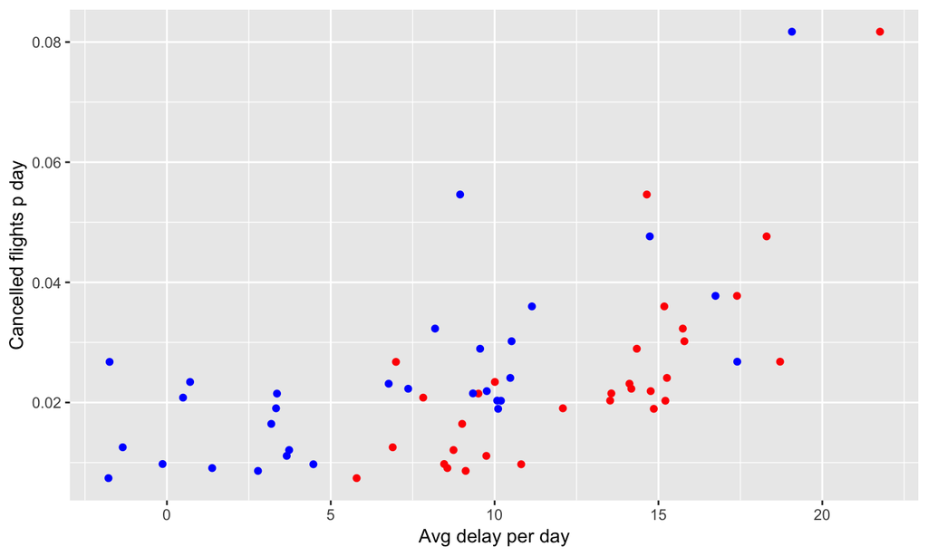

## Exercise 3

### Q5.Explore the relationship between the distance and average delay for each location

```r
> by_dest <- group_by(flights, dest)
> delay<- summarise(by_dest,
+                   count=n(),
+                   dist=mean(distance,na.rm=TRUE),
+                   delay=mean(arr_delay,na.rm=TRUE)
+ )
> delay<-filter(delay, count>20, dest!="HNL")
>
> ggplot(delay,mapping = aes(dist,delay))+
+   geom_point(aes(size=count),alpha=1/3)+
+   geom_smooth(se=FALSE)
```

## Exercise 3

```
`geom_smooth()` using method = 'loess' and formula 'y ~ x'
```

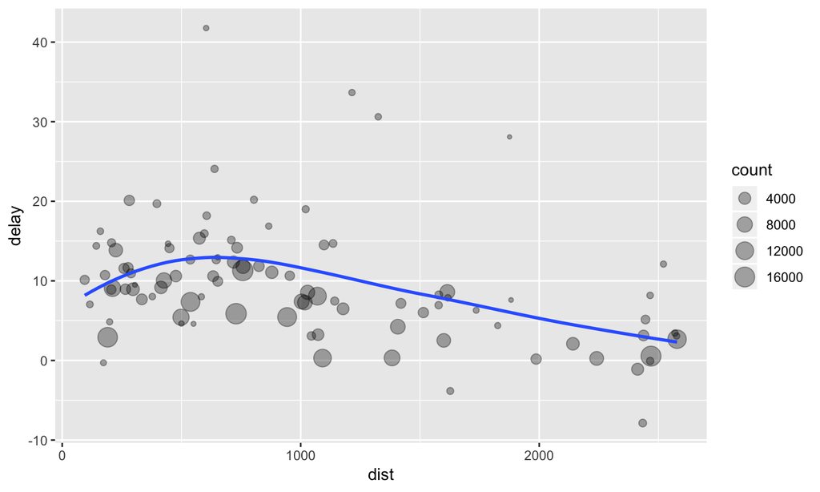

# Part VII: Brainstorm

## Find the top 10 data

### Find the 10 most delayed flights using a `ranking` function.

```r
> flights %>%
+   filter(min_rank(-(dep_delay)) %in% 1:10)
# A tibble: 10 x 19
    year month   day dep_time sched_dep_time dep_delay arr_time
   <int> <int> <int>    <int>          <int>     <dbl>    <int>
 1  2013     1     9      641            900      1301     1242
 2  2013     1    10     1121           1635      1126     1239
 3  2013    12     5      756           1700       896     1058
 4  2013     3    17     2321            810       911      135
 5  2013     4    10     1100           1900       960     1342
 6  2013     6    15     1432           1935      1137     1607
 7  2013     6    27      959           1900       899     1236
 8  2013     7    22      845           1600      1005     1044
 9  2013     7    22     2257            759       898      121
10  2013     9    20     1139           1845      1014     1457
# … with 12 more variables: sched_arr_time <int>, arr_delay <dbl>,
#   carrier <chr>, flight <int>, tailnum <chr>, origin <chr>, dest <chr>,
#   air_time <dbl>, distance <dbl>, hour <dbl>, minute <dbl>,
#   time_hour <dttm>
```

## Find the top 10 data

### Find the 10 most delayed flights using a `top_n` function

```r
> flights %>%
+   top_n(10, dep_delay)
# A tibble: 10 x 19
    year month   day dep_time sched_dep_time dep_delay arr_time
   <int> <int> <int>    <int>          <int>     <dbl>    <int>
 1  2013     1     9      641            900      1301     1242
 2  2013     1    10     1121           1635      1126     1239
 3  2013    12     5      756           1700       896     1058
 4  2013     3    17     2321            810       911      135
 5  2013     4    10     1100           1900       960     1342
 6  2013     6    15     1432           1935      1137     1607
 7  2013     6    27      959           1900       899     1236
 8  2013     7    22      845           1600      1005     1044
 9  2013     7    22     2257            759       898      121
10  2013     9    20     1139           1845      1014     1457
# … with 12 more variables: sched_arr_time <int>, arr_delay <dbl>,
#   carrier <chr>, flight <int>, tailnum <chr>, origin <chr>, dest <chr>,
#   air_time <dbl>, distance <dbl>, hour <dbl>, minute <dbl>,
#   time_hour <dttm>
```

## Find the top 10 data

### Find the 10 most delayed flights using a `head` function

```r
> flights %>%
+   arrange(-(dep_delay)) %>%
+   head(10)
# A tibble: 10 x 19
    year month   day dep_time sched_dep_time dep_delay arr_time
   <int> <int> <int>    <int>          <int>     <dbl>    <int>
 1  2013     1     9      641            900      1301     1242
 2  2013     6    15     1432           1935      1137     1607
 3  2013     1    10     1121           1635      1126     1239
 4  2013     9    20     1139           1845      1014     1457
 5  2013     7    22      845           1600      1005     1044
 6  2013     4    10     1100           1900       960     1342
 7  2013     3    17     2321            810       911      135
 8  2013     6    27      959           1900       899     1236
 9  2013     7    22     2257            759       898      121
10  2013    12     5      756           1700       896     1058
# … with 12 more variables: sched_arr_time <int>, arr_delay <dbl>,
#   carrier <chr>, flight <int>, tailnum <chr>, origin <chr>, dest <chr>,
#   air_time <dbl>, distance <dbl>, hour <dbl>, minute <dbl>,
#   time_hour <dttm>
```

## Find the top 10 data

### Find the 10 most delayed flights using a `head` function

```r
> flights %>%
+   mutate(ID = seq_along(dep_delay)) %>%
+   select(ID, everything()) %>%
+   arrange(-(dep_delay)) %>%
+   head(10)
# A tibble: 10 x 20
       ID  year month   day dep_time sched_dep_time dep_delay arr_time
    <int> <int> <int> <int>    <int>          <int>     <dbl>    <int>
 1   7073  2013     1     9      641            900      1301     1242
 2 235779  2013     6    15     1432           1935      1137     1607
 3   8240  2013     1    10     1121           1635      1126     1239
 4 327044  2013     9    20     1139           1845      1014     1457
 5 270377  2013     7    22      845           1600      1005     1044
 6 173993  2013     4    10     1100           1900       960     1342
 7 151975  2013     3    17     2321            810       911      135
 8 247041  2013     6    27      959           1900       899     1236
 9 270988  2013     7    22     2257            759       898      121
10  87239  2013    12     5      756           1700       896     1058
# … with 12 more variables: sched_arr_time <int>, arr_delay <dbl>,
#   carrier <chr>, flight <int>, tailnum <chr>, origin <chr>, dest <chr>,
#   air_time <dbl>, distance <dbl>, hour <dbl>, minute <dbl>,
#   time_hour <dttm>
```

## Find the top 10 data

### Find the rank 10th delayed flights using a `filter` function

```r
> #If you want to find the rank first or last, we can use min() & first()
> #or max() & last()
> flights %>%
+  arrange(-(dep_delay)) %>%
+   filter(1:n()==10)
# A tibble: 1 x 19
   year month   day dep_time sched_dep_time dep_delay arr_time
  <int> <int> <int>    <int>          <int>     <dbl>    <int>
1  2013    12     5      756           1700       896     1058
# … with 12 more variables: sched_arr_time <int>, arr_delay <dbl>,
#   carrier <chr>, flight <int>, tailnum <chr>, origin <chr>, dest <chr>,
#   air_time <dbl>, distance <dbl>, hour <dbl>, minute <dbl>,
#   time_hour <dttm>
```

## For both, use `range`

```r
> flights %>%
+   filter(!is.na(dep_delay), !is.na(arr_delay)) %>%
+   group_by(year, month, day) %>%
+  mutate(r = min_rank(desc(dep_time))) %>%
+   filter(r %in% range(r))
# A tibble: 770 x 20
# Groups:   year, month, day [365]
    year month   day dep_time sched_dep_time dep_delay arr_time
   <int> <int> <int>    <int>          <int>     <dbl>    <int>
 1  2013     1     1      517            515         2      830
 2  2013     1     1     2356           2359        -3      425
 3  2013     1     2       42           2359        43      518
 4  2013     1     2     2354           2359        -5      413
 5  2013     1     3       32           2359        33      504
 6  2013     1     3     2349           2359       -10      434
 7  2013     1     4       25           2359        26      505
 8  2013     1     4     2358           2359        -1      429
 9  2013     1     4     2358           2359        -1      436
10  2013     1     5       14           2359        15      503
# … with 760 more rows, and 13 more variables: sched_arr_time <int>,
#   arr_delay <dbl>, carrier <chr>, flight <int>, tailnum <chr>,
#   origin <chr>, dest <chr>, air_time <dbl>, distance <dbl>, hour <dbl>,
#   minute <dbl>, time_hour <dttm>, r <int>
```